# Validliyin Anlayışı və Növləri: Test Etibarlılığının Təməli

Klassik Test Nəzəriyyəsi - Dərs 18 (BÖLÜM 7: VALIDLIK)

Klassik Test Nəzəriyyəsi Kursu

2025-07-18

## 0.1 Dərsin Məqsədləri

✓ Validlik anlayışının əhatəli və dərin şəkildə anlanması  
✓ Üç əsas validlik növünün (məzmun, konstrukt, kriteriya) öyrənilməsi  
✓ Validlik əmsallarının hesablanması və interpretasiyası  
✓ R-da validlik analizlərinin aparılması bacarığının əldə edilməsi  
✓ Praktik şəraitlərdə validlik qiymətləndirilməsi metodlarının mənimsənilməsi

## 0.2 Əvvəlki Dərsdən Xatırladıqlarımız

**Dərs 17-də öyrəndiklərimiz:** - Norma qruplarının formalaşdırılması - Nümunə seçimi metodları və standartlaşma - Yaş və sinif normalarının qurulması - Norma cədvəllərinin yaradılması və tətbiqi

# 1 Validliyin Fundamental Anlayışı

## 1.1 Validlik Nədir?

**Validlik** - testin ölçməyə nəzərdə tutulduğu xüsusiyyəti həqiqətən ölçmə dərəcəsidir.

```r
# Validlik anlayışının əsas komponentləri
validity_components <- data.frame(
  Aspekt = c("Təyin", "Məqsəd", "Sual", "Fokus", "Qiymətləndirmə", "Nəticə"),
  İzah = c("Test nəyi ölçür?", "Nə üçün ölçür?", "Doğru ölçür?",
           "Test interpretasiyası", "Sübutların toplanması", "Qərar qəbuludur"),
  Məsələ = c("Konstrukt müəyyənliyi", "Məqsəd aydınlığı", "Ölçmə dəqiqliyi",
             "İnterpretasiya etibarlılığı", "Sübutların keyfiyyəti", "Praktik istifadə"),
  Nümunə = c("Zəka vs Yaradıcılıq", "Seçim vs Diaqnostika", "IQ = 120 doğrudur?",
             "Yüksək bal = yüksək bacarıq", "Empirik məlumatlar", "Məktəb qəbulu")
)

kable(validity_components, caption = "Validlik Anlayışının Əsas Komponentləri")
```

Validlik Anlayışının Əsas Komponentləri

| Aspekt | İzah | Məsələ | Nümunə |
| --- | --- | --- | --- |
| Təyin | Test nəyi ölçür? | Konstrukt müəyyənliyi | Zəka vs Yaradıcılıq |
| Məqsəd | Nə üçün ölçür? | Məqsəd aydınlığı | Seçim vs Diaqnostika |
| Sual | Doğru ölçür? | Ölçmə dəqiqliyi | IQ = 120 doğrudur? |
| Fokus | Test interpretasiyası | İnterpretasiya etibarlılığı | Yüksək bal = yüksək bacarıq |
| Qiymətləndirmə | Sübutların toplanması | Sübutların keyfiyyəti | Empirik məlumatlar |
| Nəticə | Qərar qəbuludur | Praktik istifadə | Məktəb qəbulu |

```r
# Validlik vs Etibarlılıq
validity_vs_reliability <- data.frame(
  Xüsusiyyət = c("Təyin", "Sual", "Fokus", "Metodlar", "Mümkün Nəticə", "Asılılıq"),
  Validlik = c("Doğruluq", "Test nəyi ölçür?", "Məzmun və interpretasiya",
               "Korrelyasiya, faktör analizi", "Valid lakin qeyri-etibarlı mümkündür",
               "Etibarlılıqdan asılıdır"),
  Etibarlılıq = c("Davamlılıq", "Test nə qədər sabitdir?", "Ölçmə stabilliyi",
                  "Test-retest, daxili tutarlılıq", "Etibarlı lakin qeyri-valid mümkündür",
                  "Validlikdən müstəqildir")
)

kable(validity_vs_reliability, caption = "Validlik və Etibarlılıq Arasındakı Fərqlər")
```

Validlik və Etibarlılıq Arasındakı Fərqlər

| Xüsusiyyət | Validlik | Etibarlılıq |
| --- | --- | --- |
| Təyin | Doğruluq | Davamlılıq |
| Sual | Test nəyi ölçür? | Test nə qədər sabitdir? |
| Fokus | Məzmun və interpretasiya | Ölçmə stabilliyi |
| Metodlar | Korrelyasiya, faktör analizi | Test-retest, daxili tutarlılıq |
| Mümkün Nəticə | Valid lakin qeyri-etibarlı mümkündür | Etibarlı lakin qeyri-valid mümkündür |
| Asılılıq | Etibarlılıqdan asılıdır | Validlikdən müstəqildir |

```r
# Validlik növlərinin ümumi təsnifatı
validity_types <- data.frame(
  Validlik_Növü = c("Məzmun Validliyi", "Konstrukt Validliyi", "Kriteriya Validliyi"),
  Əsas_Sual = c("Test məzmunu uyğundur?", "Test nəzəri konstruktu ölçür?",
                "Test praktik kriteriya ilə əlaqəlidir?"),
  Metodlar = c("Ekspert qiymətləndirməsi", "Faktör analizi", "Korrelyasiya analizi"),
  Tətbiq_Sahəsi = c("Məzmun əsaslı testlər", "Psixoloji testlər", "Proqnostik testlər"),
  Nümunə = c("Riyaziyyat testi", "Şəxsiyyət testi", "Aptitude testi")
)

kable(validity_types, caption = "Validlik Növlərinin Ümumi Təsnifatı")
```

Validlik Növlərinin Ümumi Təsnifatı

| Validlik_Növü | Əsas_Sual | Metodlar | Tətbiq_Sahəsi | Nümunə |
| --- | --- | --- | --- | --- |
| Məzmun Validliyi | Test məzmunu uyğundur? | Ekspert qiymətləndirməsi | Məzmun əsaslı testlər | Riyaziyyat testi |
| Konstrukt Validliyi | Test nəzəri konstruktu ölçür? | Faktör analizi | Psixoloji testlər | Şəxsiyyət testi |
| Kriteriya Validliyi | Test praktik kriteriya ilə əlaqəlidir? | Korrelyasiya analizi | Proqnostik testlər | Aptitude testi |

## 1.2 Validliyin Tarixi İnkişafı

```r
# Validlik anlayışının tarixi inkişafı
validity_evolution <- data.frame(
  Dövr = c("1900-1950", "1950-1970", "1970-1990", "1990-2010", "2010-İndiki"),
  Yanaşma = c("Sadə Korrelyasiya", "Üç Validlik Növü", "Konstrukt Validliyi",
              "Unified Validity", "Evidence-Based Validity"),
  Əsas_Fokus = c("Kriteriya əlaqəsi", "Təsnifat sistemi", "Nəzəri əsaslar",
                 "Bütövlük", "Sübutlar toplusu"),
  Metodlar = c("Pearson korrelyasiyası", "Faktör analizi", "MTMM, CFA",
               "Meta-analiz", "Bayes, IRT"),
  Nümayəndələr = c("Galton, Spearman", "Cronbach, Meehl", "Campbell, Fiske",
                   "Messick", "Kane, Mislevy")
)

kable(validity_evolution, caption = "Validlik Anlayışının Tarixi İnkişafı")
```

Validlik Anlayışının Tarixi İnkişafı

| Dövr | Yanaşma | Əsas_Fokus | Metodlar | Nümayəndələr |
| --- | --- | --- | --- | --- |
| 1900-1950 | Sadə Korrelyasiya | Kriteriya əlaqəsi | Pearson korrelyasiyası | Galton, Spearman |
| 1950-1970 | Üç Validlik Növü | Təsnifat sistemi | Faktör analizi | Cronbach, Meehl |
| 1970-1990 | Konstrukt Validliyi | Nəzəri əsaslar | MTMM, CFA | Campbell, Fiske |
| 1990-2010 | Unified Validity | Bütövlük | Meta-analiz | Messick |
| 2010-İndiki | Evidence-Based Validity | Sübutlar toplusu | Bayes, IRT | Kane, Mislevy |

```r
# Müasir validlik framework-ü
modern_validity_framework <- data.frame(
  Prinsip = c("Unified Concept", "Evidence-Based", "Interpretasiya Fokus",
              "Kontekst Asılılığı", "Sübutların İnteqrasiyası"),
  İzah = c("Validlik vahid anlayışdır", "Empirik sübutlara əsaslanır",
           "Test interpretasiyasına yönəldilir", "İstifadə kontekstindən asılıdır",
           "Müxtəlif mənbələrdən sübutlar"),
  Praktik_Məna = c("Növlər arası fərq azalır", "Məlumat əsaslı qərarlar",
                   "İstifadə məqsədi vacibdir", "Kontekstə uyğun validasiya",
                   "Çoxsahəli validlik sübutu"),
  Çağırış = c("Metodoloji dəqiqlik", "Sübutların keyfiyyəti",
              "Təfsir standartları", "Adaptasiya zərurəti", "Kompleks analiz")
)

kable(modern_validity_framework, caption = "Müasir Validlik Framework-ünün Prinsipləri")
```

Müasir Validlik Framework-ünün Prinsipləri

| Prinsip | İzah | Praktik_Məna | Çağırış |
| --- | --- | --- | --- |
| Unified Concept | Validlik vahid anlayışdır | Növlər arası fərq azalır | Metodoloji dəqiqlik |
| Evidence-Based | Empirik sübutlara əsaslanır | Məlumat əsaslı qərarlar | Sübutların keyfiyyəti |
| Interpretasiya Fokus | Test interpretasiyasına yönəldilir | İstifadə məqsədi vacibdir | Təfsir standartları |
| Kontekst Asılılığı | İstifadə kontekstindən asılıdır | Kontekstə uyğun validasiya | Adaptasiya zərurəti |
| Sübutların İnteqrasiyası | Müxtəlif mənbələrdən sübutlar | Çoxsahəli validlik sübutu | Kompleks analiz |

```r
# Validlik sübutlarının mənbələri (Kane, 2006)
validity_evidence_sources <- data.frame(
  Sübutlar_Mənbəyi = c("Test Məzmunu", "Cavab Prosesi", "Daxili Struktur",
                       "Digər Dəyişənlərlə Əlaqə", "İstifadənin Nəticələri"),
  Suallar = c("Məzmun uyğundur?", "Düşüncə prosesi hansıdır?", "Struktur nəzəriyyəyə uyğundur?",
              "Gözlənilən əlaqələr mövcuddur?", "İstifadənin nəticələri nədir?"),
  Metodlar = c("Ekspert qiymətləndirməsi", "Think-aloud protokolları", "Faktör analizi",
               "Korrelyasiya, diskriminant", "İmpakt araşdırması"),
  Nümunə = c("Kurrikulum uyğunluğu", "Problem həlli strategiyaları", "Çoxfaktorlu struktur",
             "Akademik müvəffəqiyyət əlaqəsi", "Təhsil bərabərliyinə təsir")
)

kable(validity_evidence_sources, caption = "Validlik Sübutlarının Beş Əsas Mənbəyi")
```

Validlik Sübutlarının Beş Əsas Mənbəyi

| Sübutlar_Mənbəyi | Suallar | Metodlar | Nümunə |
| --- | --- | --- | --- |
| Test Məzmunu | Məzmun uyğundur? | Ekspert qiymətləndirməsi | Kurrikulum uyğunluğu |
| Cavab Prosesi | Düşüncə prosesi hansıdır? | Think-aloud protokolları | Problem həlli strategiyaları |
| Daxili Struktur | Struktur nəzəriyyəyə uyğundur? | Faktör analizi | Çoxfaktorlu struktur |
| Digər Dəyişənlərlə Əlaqə | Gözlənilən əlaqələr mövcuddur? | Korrelyasiya, diskriminant | Akademik müvəffəqiyyət əlaqəsi |
| İstifadənin Nəticələri | İstifadənin nəticələri nədir? | İmpakt araşdırması | Təhsil bərabərliyinə təsir |

# 2 Məzmun Validliyi

## 2.1 Məzmun Validliyinin Mahiyyəti

**Məzmun validliyi** - testin məzmununun ölçülməsi nəzərdə tutulan sahənin nümayəndə hissəsi olma dərəcəsidir.

```r
# Məzmun validliyinin komponentləri
content_validity_components <- data.frame(
  Komponent = c("Məzmun Əhatəsi", "Məzmun Uyğunluğu", "Məzmun Balansı",
                "Məzmun Reprezentativliyi", "Məzmun Səviyyəsi"),
  Təsvir = c("Bütün vacib sahələri əhatə etmə", "Hər bənd uyğun məzmunda",
             "Sahələr arasında mütənasib paylanma", "Populyasiyanı təmsil etmə",
             "Uyğun çətinlik səviyyəsi"),
  Qiymətləndirmə = c("Spesifikasiya cədvəli", "Ekspert qiymətləndirməsi",
                     "Məzmun analizi", "Kurrikulum uyğunluğu", "Çətinlik analizi"),
  Göstərici = c("Əhatə faizi", "Uyğunluq reytinqi", "Bölgü əmsalı",
                "Təmsil indeksi", "Çətinlik səviyyəsi")
)

kable(content_validity_components, caption = "Məzmun Validliyinin Əsas Komponentləri")
```

Məzmun Validliyinin Əsas Komponentləri

| Komponent | Təsvir | Qiymətləndirmə | Göstərici |
| --- | --- | --- | --- |
| Məzmun Əhatəsi | Bütün vacib sahələri əhatə etmə | Spesifikasiya cədvəli | Əhatə faizi |
| Məzmun Uyğunluğu | Hər bənd uyğun məzmunda | Ekspert qiymətləndirməsi | Uyğunluq reytinqi |
| Məzmun Balansı | Sahələr arasında mütənasib paylanma | Məzmun analizi | Bölgü əmsalı |
| Məzmun Reprezentativliyi | Populyasiyanı təmsil etmə | Kurrikulum uyğunluğu | Təmsil indeksi |
| Məzmun Səviyyəsi | Uyğun çətinlik səviyyəsi | Çətinlik analizi | Çətinlik səviyyəsi |

```r
# Məzmun validliği qiymətləndirməsi nümunəsi
# Riyaziyyat testinin məzmun validliyi
math_content_areas <- data.frame(
  Məzmun_Sahəsi = c("Rəqəmlər və Əməliyyatlar", "Həndəsə", "Ölçü", "Məlumat Analizi", "Cəbir"),
  Kurrikulum_Çəkisi = c(30, 25, 20, 15, 10),
  Test_Çəkisi = c(35, 20, 18, 12, 15),
  Fərq = c(5, -5, -2, -3, 5),
  Uyğunluq_Reytinqi = c("Yaxşı", "Orta", "Yaxşı", "Orta", "Zəif")
)

kable(math_content_areas, caption = "Riyaziyyat Testinin Məzmun Validliyi Analizi")
```

Riyaziyyat Testinin Məzmun Validliyi Analizi

| Məzmun_Sahəsi | Kurrikulum_Çəkisi | Test_Çəkisi | Fərq | Uyğunluq_Reytinqi |
| --- | --- | --- | --- | --- |
| Rəqəmlər və Əməliyyatlar | 30 | 35 | 5 | Yaxşı |
| Həndəsə | 25 | 20 | -5 | Orta |
| Ölçü | 20 | 18 | -2 | Yaxşı |
| Məlumat Analizi | 15 | 12 | -3 | Orta |
| Cəbir | 10 | 15 | 5 | Zəif |

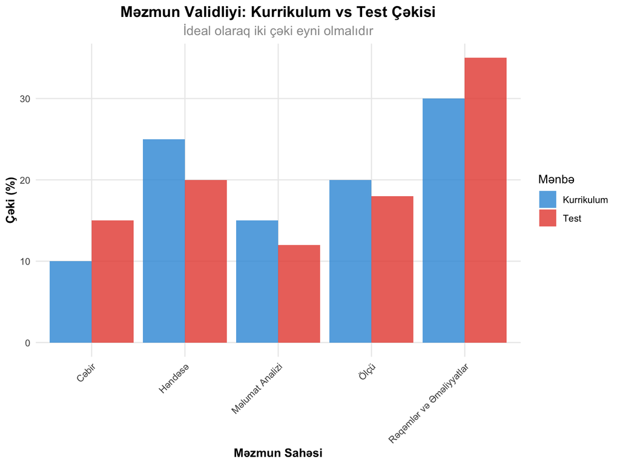

```r
# Məzmun validliyi vizuallaşma
content_comparison <- math_content_areas %>%
  select(Məzmun_Sahəsi, Kurrikulum_Çəkisi, Test_Çəkisi) %>%
  pivot_longer(cols = c(Kurrikulum_Çəkisi, Test_Çəkisi),
               names_to = "Mənbə", values_to = "Çəki")

ggplot(content_comparison, aes(x = Məzmun_Sahəsi, y = Çəki, fill = Mənbə)) +
  geom_col(position = "dodge", alpha = 0.8) +
  scale_fill_manual(values = colors_basic[1:2],
                    labels = c("Kurrikulum", "Test")) +
  labs(title = "Məzmun Validliyi: Kurrikulum vs Test Çəkisi",
       subtitle = "İdeal olaraq iki çəki eyni olmalıdır",
       x = "Məzmun Sahəsi", y = "Çəki (%)", fill = "Mənbə") +
  theme_clean() +
  theme(axis.text.x = element_text(angle = 45, hjust = 1))
```

```r
# Content Validity Ratio (CVR) hesablaması
calculate_cvr <- function(n_essential, n_total) {
  cvr <- (n_essential - (n_total / 2)) / (n_total / 2)
  return(cvr)
}

# CVR nümunəsi
cvr_example <- data.frame(
  Bənd_ID = paste0("B", 1:10),
  Ekspert_Sayı = rep(8, 10),
  Vacib_Deyən = c(8, 7, 6, 8, 5, 7, 8, 4, 6, 7),
  CVR = round(calculate_cvr(c(8, 7, 6, 8, 5, 7, 8, 4, 6, 7), 8), 2),
  Qiymət = ifelse(calculate_cvr(c(8, 7, 6, 8, 5, 7, 8, 4, 6, 7), 8) >= 0.75,
                  "Qəbul", "Rədd")
)

kable(cvr_example, caption = "Content Validity Ratio (CVR) Hesablama Nümunəsi")
```

Content Validity Ratio (CVR) Hesablama Nümunəsi

| Bənd_ID | Ekspert_Sayı | Vacib_Deyən | CVR | Qiymət |
| --- | --- | --- | --- | --- |
| B1 | 8 | 8 | 1.00 | Qəbul |
| B2 | 8 | 7 | 0.75 | Qəbul |
| B3 | 8 | 6 | 0.50 | Rədd |
| B4 | 8 | 8 | 1.00 | Qəbul |
| B5 | 8 | 5 | 0.25 | Rədd |
| B6 | 8 | 7 | 0.75 | Qəbul |
| B7 | 8 | 8 | 1.00 | Qəbul |
| B8 | 8 | 4 | 0.00 | Rədd |
| B9 | 8 | 6 | 0.50 | Rədd |
| B10 | 8 | 7 | 0.75 | Qəbul |

```r
# Məzmun validliyi üçün ekspert qiymətləndirməsi
expert_rating_criteria <- data.frame(
  Qiymətləndirmə_Aspekti = c("Məzmun Uyğunluğu", "Dil Aydınlığı", "Çətinlik Səviyyəsi",
                             "Mədəni Uyğunluq", "Diskriminasiya Potensialı"),
  Skala = c("1-4 (çox uyğun)", "1-4 (çox aydın)", "1-4 (çox uyğun)",
            "1-4 (çox uyğun)", "1-4 (çox yüksək)"),
  Qəbul_Kriteriyası = c("≥ 3.0", "≥ 3.0", "2.5-3.5", "≥ 3.0", "≥ 3.0"),
  Qeyd = c("Konstrukta uyğunluq", "Anlaşıqlıq", "Hədəf qrupa uyğun",
           "Bias-dan azad", "Qrupları ayıra bilmək")
)

kable(expert_rating_criteria, caption = "Ekspert Qiymətləndirməsi Kriteriyaları")
```

Ekspert Qiymətləndirməsi Kriteriyaları

| Qiymətləndirmə_Aspekti | Skala | Qəbul_Kriteriyası | Qeyd |
| --- | --- | --- | --- |
| Məzmun Uyğunluğu | 1-4 (çox uyğun) | ≥ 3.0 | Konstrukta uyğunluq |
| Dil Aydınlığı | 1-4 (çox aydın) | ≥ 3.0 | Anlaşıqlıq |
| Çətinlik Səviyyəsi | 1-4 (çox uyğun) | 2.5-3.5 | Hədəf qrupa uyğun |
| Mədəni Uyğunluq | 1-4 (çox uyğun) | ≥ 3.0 | Bias-dan azad |
| Diskriminasiya Potensialı | 1-4 (çox yüksək) | ≥ 3.0 | Qrupları ayıra bilmək |

## 2.2 Məzmun Validliyinin Qiymətləndirilməsi

```r
# Lawshe Content Validity Index
calculate_cvi <- function(cvr_values) {
  valid_items <- cvr_values[cvr_values >= 0.62] # 8 ekspert üçün critical value
  cvi <- length(valid_items) / length(cvr_values)
  return(cvi)
}

# CVI hesablaması
cvi_result <- calculate_cvi(cvr_example$CVR)

content_validity_summary <- data.frame(
  Göstərici = c("Ümumi Bənd Sayı", "Qəbul Edilən Bənd", "CVI", "Qiymət"),
  Dəyər = c(nrow(cvr_example),
            sum(cvr_example$CVR >= 0.62),
            round(cvi_result, 3),
            ifelse(cvi_result >= 0.80, "Yüksək", ifelse(cvi_result >= 0.60, "Orta", "Aşağı")))
)

kable(content_validity_summary, caption = "Testin Ümumi Məzmun Validliyi İndeksi (CVI)")
```

Testin Ümumi Məzmun Validliyi İndeksi (CVI)

| Göstərici | Dəyər |
| --- | --- |
| Ümumi Bənd Sayı | 10 |
| Qəbul Edilən Bənd | 6 |
| CVI | 0.6 |
| Qiymət | Orta |

```r
# Məzmun validliyi qiymətləndirmə proseduru
content_validation_procedure <- data.frame(
  Mərhələ = c("1. Planlaşdırma", "2. Ekspert Seçimi", "3. Materialların Hazırlanması",
              "4. Qiymətləndirmə", "5. Analiz", "6. Qərar"),
  Fəaliyyət = c("Məqsəd və kriteriyaların müəyyənləşdirilməsi",
                "Sahə ekspertlərinin seçilməsi",
                "Test və qiymətləndirmə formalarının hazırlanması",
                "Ekspertlərin müstəqil qiymətləndirməsi",
                "CVR/CVI hesablanması və statistik analiz",
                "Bəndlərin saxlanması/dəyişdirilməsi/silinməsi"),
  Çıxış = c("Validasiya planı", "Ekspert paneli", "Qiymətləndirmə materialları",
            "Ekspert reytingləri", "Statistik nəticələr", "Final test forması"),
  Keyfiyyət_Kriteriyası = c("Aydın məqsədlər", "5-10 ekspert", "Strukturlu formalar",
                            "Müstəqil qiymətləndirmə", "Uyğun statistikalar", "Məntiqli qərar")
)

kable(content_validation_procedure, caption = "Məzmun Validasiyası Proseduru")
```

Məzmun Validasiyası Proseduru

| Mərhələ | Fəaliyyət | Çıxış | Keyfiyyət_Kriteriyası |
| --- | --- | --- | --- |
| 1. Planlaşdırma | Məqsəd və kriteriyaların müəyyənləşdirilməsi | Validasiya planı | Aydın məqsədlər |
| 2. Ekspert Seçimi | Sahə ekspertlərinin seçilməsi | Ekspert paneli | 5-10 ekspert |
| 3. Materialların Hazırlanması | Test və qiymətləndirmə formalarının hazırlanması | Qiymətləndirmə materialları | Strukturlu formalar |
| 4. Qiymətləndirmə | Ekspertlərin müstəqil qiymətləndirməsi | Ekspert reytingləri | Müstəqil qiymətləndirmə |
| 5. Analiz | CVR/CVI hesablanması və statistik analiz | Statistik nəticələr | Uyğun statistikalar |
| 6. Qərar | Bəndlərin saxlanması/dəyişdirilməsi/silinməsi | Final test forması | Məntiqli qərar |

```r
# Ekspert rəyləri analizi
expert_opinions <- data.frame(
  Bend = paste0("Bend_", 1:8),
  Ekspert_1 = c(4, 3, 4, 2, 4, 3, 4, 3),
  Ekspert_2 = c(4, 4, 3, 3, 4, 4, 4, 2),
  Ekspert_3 = c(3, 3, 4, 2, 3, 3, 4, 3),
  Ekspert_4 = c(4, 4, 4, 3, 4, 3, 3, 2),
  Ekspert_5 = c(4, 3, 3, 2, 4, 4, 4, 3)
)

# Orta reytinqlər
expert_opinions$Orta <- round(rowMeans(expert_opinions[, 2:6]), 2)
expert_opinions$SD <- round(apply(expert_opinions[, 2:6], 1, sd), 2)
expert_opinions$CVR <- round(calculate_cvr(rowSums(expert_opinions[, 2:6] >= 3), 5), 2)

kable(expert_opinions, caption = "Ekspert Qiymətləndirmələri və Analiz Nəticələri")
```

Ekspert Qiymətləndirmələri və Analiz Nəticələri

| Bend | Ekspert_1 | Ekspert_2 | Ekspert_3 | Ekspert_4 | Ekspert_5 | Orta | SD | CVR |
| --- | --- | --- | --- | --- | --- | --- | --- | --- |
| Bend_1 | 4 | 4 | 3 | 4 | 4 | 3.8 | 0.45 | 1.0 |
| Bend_2 | 3 | 4 | 3 | 4 | 3 | 3.4 | 0.55 | 1.0 |
| Bend_3 | 4 | 3 | 4 | 4 | 3 | 3.6 | 0.55 | 1.0 |
| Bend_4 | 2 | 3 | 2 | 3 | 2 | 2.4 | 0.55 | -0.2 |
| Bend_5 | 4 | 4 | 3 | 4 | 4 | 3.8 | 0.45 | 1.0 |
| Bend_6 | 3 | 4 | 3 | 3 | 4 | 3.4 | 0.55 | 1.0 |
| Bend_7 | 4 | 4 | 4 | 3 | 4 | 3.8 | 0.45 | 1.0 |
| Bend_8 | 3 | 2 | 3 | 2 | 3 | 2.6 | 0.55 | 0.2 |

```r
# Məzmun sahələri üzrə əhatə analizi
content_coverage_analysis <- function(test_items, content_areas, target_distribution) {
  actual_distribution <- table(factor(test_items, levels = content_areas))
  coverage_analysis <- data.frame(
    Məzmun_Sahəsi = content_areas,
    Hədəf_Faiz = target_distribution,
    Faktiki_Say = as.numeric(actual_distribution),
    Faktiki_Faiz = round(as.numeric(actual_distribution) / sum(actual_distribution) * 100, 1),
    Fərq = round(as.numeric(actual_distribution) / sum(actual_distribution) * 100 - target_distribution, 1)
  )
  return(coverage_analysis)
}

# Nümunə istifadə
# Test məlumatları yaradırıq
set.seed(2023)
n <- 150

test_data <- data.frame(
  Verbal_Test = round(rnorm(n, 500, 100), 0),
  Math_Test = round(rnorm(n, 520, 95), 0),
  Reasoning_Test = round(rnorm(n, 75, 12), 0)
)

# Kriteriya yaradırıq (akademik performans)
test_data$Academic_Performance <- round(
  50 + 0.02 * test_data$Verbal_Test +
  0.015 * test_data$Math_Test +
  0.3 * test_data$Reasoning_Test +
  rnorm(n, 0, 8), 1)

# Çoxlu validlik analizi
multiple_validity_results <- ValidityAnalyzer$multiple_validity(
  predictors_df = test_data[, 1:3],
  criterion = test_data$Academic_Performance
)

kable(multiple_validity_results$summary, caption = "Çoxlu Validlik Analizi Nəticələri", digits = 4)
```

[output not shown]

Çoxlu Validlik Analizi Nəticələri

|  | Predictor | Correlation | P_Value | Lower_CI | Upper_CI | Interpretation |
| --- | --- | --- | --- | --- | --- | --- |
| Verbal_Test | Verbal_Test | 0.3089 | 0.0001 | 0.1564 | 0.4470 | orta əlaqə |
| Math_Test | Math_Test | 0.2038 | 0.0124 | 0.0450 | 0.3525 | orta əlaqə |
| Reasoning_Test | Reasoning_Test | 0.3082 | 0.0001 | 0.1556 | 0.4464 | orta əlaqə |

```r
# İnkremental validlik analizi
incremental_results <- ValidityAnalyzer$incremental_validity(
  baseline_predictors = test_data$Verbal_Test,
  additional_predictors = test_data[, c("Math_Test", "Reasoning_Test")],
  criterion = test_data$Academic_Performance
)

incremental_summary <- data.frame(
  Metrik = c("Baseline R", "Baseline R²", "Combined R", "Combined R²",
             "ΔR²", "Artım %", "İnterpretasiya"),
  Deyer = c(incremental_results$baseline_r,
            incremental_results$baseline_r2,
            incremental_results$combined_r,
            incremental_results$combined_r2,
            incremental_results$delta_r2,
            paste0(incremental_results$percentage_improvement, "%"),
            incremental_results$interpretation)
)

kable(incremental_summary, caption = "İnkremental Validlik Analizi")
```

İnkremental Validlik Analizi

| Metrik | Deyer |
| --- | --- |
| Baseline R | 0.3089 |
| Baseline R² | 0.0954 |
| Combined R | 0.3588 |
| Combined R² | 0.1287 |
| ΔR² | 0.0333 |
| Artım % | 3.33% |
| İnterpretasiya | Kiçik artım |

```r
# Aralıq məhdudiyyəti düzəlişi nümunəsi
restriction_correction <- ValidityAnalyzer$range_restriction_correction(
  observed_r = 0.35,
  observed_sd = 85,
  unrestricted_sd = 100
)

restriction_summary <- data.frame(
  Gosterici = c("Müşahidə olunan validlik", "Düzəldilmiş validlik",
                "Düzəliş faktoru", "İyiləşmə"),
  Deyer = c(restriction_correction$observed_validity,
            restriction_correction$corrected_validity,
            restriction_correction$correction_factor,
            restriction_correction$improvement)
)

kable(restriction_summary, caption = "Aralıq Məhdudiyyəti Düzəlişi")
```

Aralıq Məhdudiyyəti Düzəlişi

| Gosterici | Deyer |
| --- | --- |
| Müşahidə olunan validlik | 0.3500 |
| Düzəldilmiş validlik | 0.4024 |
| Düzəliş faktoru | 1.1765 |
| İyiləşmə | 0.0524 |

## 2.3 Validlik Vizuallaşma və Hesabat

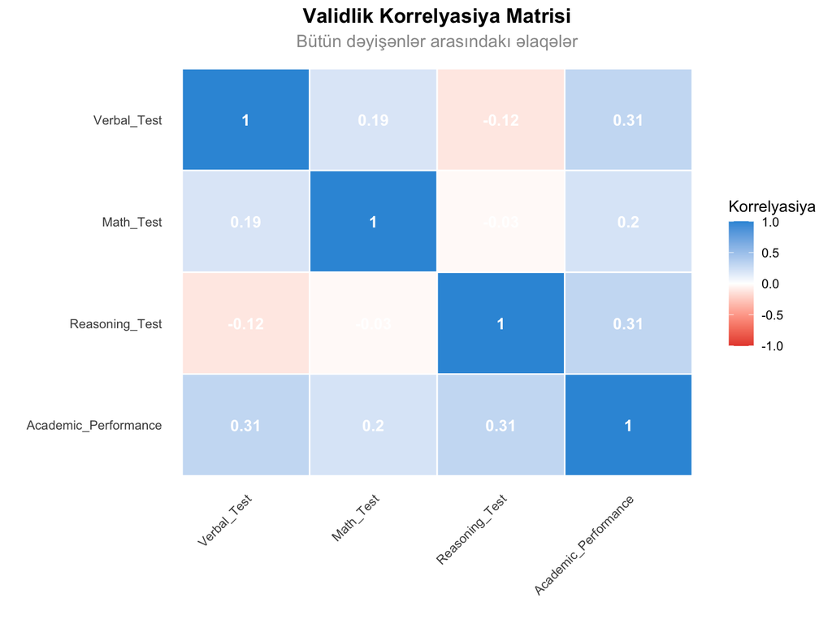

```r
# Validlik hesabat generatoru
generate_validity_report <- function(data, predictors, criterion, test_names = NULL) {

  if(is.null(test_names)) {
    test_names <- predictors
  }

  cat("\n", "="*60, "\n")
  cat("VALİDLİK ANALİZİ HESABATI\n")
  cat("="*60, "\n\n")

  cat("TƏSVİRİ STATİSTİKALAR\n")
  cat("-"*30, "\n")

  # Təsviri statistikalar
  desc_stats <- data %>%
    select(all_of(c(predictors, criterion))) %>%
    summarise_all(list(
      N = ~ sum(!is.na(.)),
      Mean = ~ round(mean(., na.rm = TRUE), 2),
      SD = ~ round(sd(., na.rm = TRUE), 2),
      Min = ~ round(min(., na.rm = TRUE), 1),
      Max = ~ round(max(., na.rm = TRUE), 1)
    ))

  print(t(desc_stats))

  cat("\n\nVALİDLİK KORRELYASİYALARI\n")
  cat("-"*30, "\n")

  # Validlik korrelyasiyaları
  validity_results <- ValidityAnalyzer$multiple_validity(
    data[predictors], data[[criterion]])

  print(validity_results$summary)

  cat("\n\nVALİDLİK İNTERPRETASİYASI\n")
  cat("-"*30, "\n")

  # İnterpretasiya cədvəli
  interpretation_table <- validity_results$summary %>%
    mutate(
      Practical_Significance = ifelse(abs(Correlation) < 0.2, "Praktik əhəmiyyətsiz",
                                     ifelse(abs(Correlation) < 0.5, "Praktik əhəmiyyətli",
                                           "Çox əhəmiyyətli")),
      R_Squared = round(Correlation^2, 3),
      Shared_Variance = paste0(round(Correlation^2 * 100, 1), "%")
    ) %>%
    select(Predictor, Correlation, R_Squared, Shared_Variance, Practical_Significance)

  print(interpretation_table)

  # Vizuallaşma
  validity_plot_data <- validity_results$summary %>%
    mutate(Abs_Correlation = abs(Correlation),
           Direction = ifelse(Correlation > 0, "Müsbət", "Mənfi"))

  p1 <- ggplot(validity_plot_data, aes(x = reorder(Predictor, Abs_Correlation),
                                       y = Correlation, fill = Direction)) +
    geom_col(alpha = 0.8, width = 0.6) +
    geom_text(aes(label = round(Correlation, 3)),
              hjust = ifelse(validity_plot_data$Correlation > 0, -0.1, 1.1)) +
    coord_flip() +
    scale_fill_manual(values = c("Müsbət" = colors_basic[1], "Mənfi" = colors_basic[2])) +
    labs(title = "Validlik Korrelyasiyaları",
         subtitle = "Prediktorların kriteriya ilə əlaqəsi",
         x = "Prediktor", y = "Korrelyasiya Əmsalı", fill = "İstiqamət") +
    theme_clean()

  print(p1)

  cat("\n\nTÖVSİYƏLƏR\n")
  cat("-"*30, "\n")

  # Avtomatik tövsiyələr
  max_validity <- max(abs(validity_results$summary$Correlation))
  best_predictor <- validity_results$summary$Predictor[which.max(abs(validity_results$summary$Correlation))]

  cat("• Ən güclü prediktor:", best_predictor, "(r =", round(max_validity, 3), ")\n")

  if(max_validity > 0.5) {
    cat("• Validlik səviyyəsi: YÜKSƏK - praktik istifadə üçün uyğundur\n")
  } else if(max_validity > 0.3) {
    cat("• Validlik səviyyəsi: ORTA - digər prediktorlarla birlikdə istifadə tövsiyə olunur\n")
  } else {
    cat("• Validlik səviyyəsi: AŞAĞI - testin yenidən nəzərdən keçirilməsi tövsiyə olunur\n")
  }

  cat("• Kombinə validlik üçün çoxlu reqressiya analizi aparın\n")
  cat("• Konstrukt validliyi üçün faktör analizini nəzərə alın\n")

  cat("\n", "="*60, "\n")

  return(list(
    descriptive = desc_stats,
    validity = validity_results,
    interpretation = interpretation_table,
    plot = p1
  ))
}

# Korrelyasiya matrisi vizuallaşma
correlation_matrix <- cor(test_data, use = "complete.obs")

# Base R ilə korrelyasiya plot-u
correlation_plot_data <- expand.grid(
  Var1 = rownames(correlation_matrix),
  Var2 = colnames(correlation_matrix)
) %>%
  mutate(
    Correlation = as.vector(correlation_matrix),
    Var1 = factor(Var1, levels = rev(rownames(correlation_matrix))),
    Var2 = factor(Var2, levels = colnames(correlation_matrix))
  )

ggplot(correlation_plot_data, aes(x = Var2, y = Var1, fill = Correlation)) +
  geom_tile(color = "white", size = 0.5) +
  geom_text(aes(label = round(Correlation, 2)), color = "white", fontface = "bold") +
  scale_fill_gradient2(low = colors_basic[2], mid = "white", high = colors_basic[1],
                       midpoint = 0, limit = c(-1, 1)) +
  labs(title = "Validlik Korrelyasiya Matrisi",
       subtitle = "Bütün dəyişənlər arasındakı əlaqələr",
       x = "", y = "", fill = "Korrelyasiya") +
  theme_clean() +
  theme(axis.text.x = element_text(angle = 45, hjust = 1),
        panel.grid = element_blank())
```

```r
# Validlik əmsalının güven intervalları
confidence_intervals <- data.frame(
  Test = c("Verbal Test", "Math Test", "Reasoning Test"),
  Correlation = round(c(cor(test_data$Verbal_Test, test_data$Academic_Performance),
                       cor(test_data$Math_Test, test_data$Academic_Performance),
                       cor(test_data$Reasoning_Test, test_data$Academic_Performance)), 3),
  Lower_CI = numeric(3),
  Upper_CI = numeric(3)
)

# Güven intervallarını hesablayırıq
for(i in 1:3) {
  predictor <- test_data[, i]
  criterion <- test_data$Academic_Performance

  result <- ValidityAnalyzer$validity_correlation(predictor, criterion)
  confidence_intervals$Lower_CI[i] <- result$confidence_interval[1]
  confidence_intervals$Upper_CI[i] <- result$confidence_interval[2]
}

kable(confidence_intervals, caption = "Validlik Əmsallarının 95% Güvən İntervalları", digits = 3)
```

Validlik Əmsallarının 95% Güvən İntervalları

| Test | Correlation | Lower_CI | Upper_CI |
| --- | --- | --- | --- |
| Verbal Test | 0.309 | 0.156 | 0.447 |
| Math Test | 0.204 | 0.045 | 0.352 |
| Reasoning Test | 0.308 | 0.156 | 0.446 |

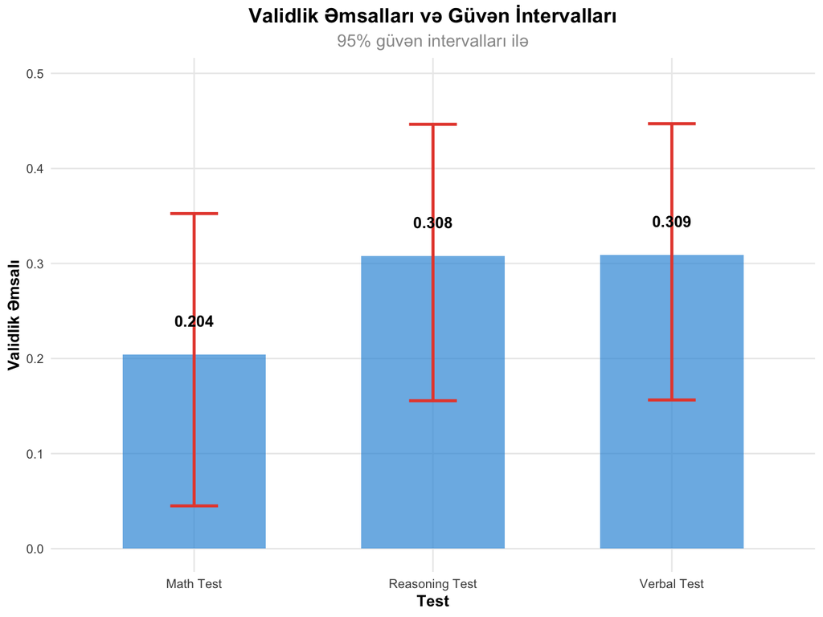

```r
# Error bar plot
ggplot(confidence_intervals, aes(x = Test, y = Correlation)) +
  geom_col(fill = colors_basic[1], alpha = 0.7, width = 0.6) +
  geom_errorbar(aes(ymin = Lower_CI, ymax = Upper_CI),
                width = 0.2, color = colors_basic[2], size = 1) +
  geom_text(aes(label = round(Correlation, 3)), vjust = -2.5, fontface = "bold") +
  labs(title = "Validlik Əmsalları və Güvən İntervalları",
       subtitle = "95% güvən intervalları ilə",
       x = "Test", y = "Validlik Əmsalı") +
  theme_clean() +
  ylim(0, max(confidence_intervals$Upper_CI) * 1.1)
```

# 3 Tapşırıq: Müxtəlif Validlik Növlərinin Qiymətləndirilməsi

## 3.1 Praktik Tapşırıq (60 xal)

```r
# VERİLMİŞ SİMULYASİYA MƏLUMATLARI
set.seed(sizin_tələbə_nömrəniz) # Öz nömrənizi yazın

# 300 iştirakçı üçün test batareyası
n_participants <- 300

homework_data <- data.frame(
  Participant_ID = paste0("P", sprintf("%03d", 1:n_participants)),

  # Demografik məlumatlar
  Age = sample(18:65, n_participants, replace = TRUE),
  Gender = sample(c("Kişi", "Qadın"), n_participants, replace = TRUE),
  Education = sample(c("Orta", "Bakalavr", "Magistr"), n_participants, replace = TRUE,
                     prob = c(0.4, 0.4, 0.2)),

  # Test nəticələri
  Verbal_Aptitude = round(rnorm(n_participants, 100, 15), 0),
  Numerical_Aptitude = round(rnorm(n_participants, 105, 12), 0),
  Logical_Reasoning = round(rnorm(n_participants, 75, 10), 0),
  Spatial_Ability = round(rnorm(n_participants, 85, 8), 0),
  Personality_Score = round(rnorm(n_participants, 60, 12), 0),

  # Kriteriya məlumatları
  Job_Performance = round(rnorm(n_participants, 70, 15), 1),
  Academic_Success = round(rnorm(n_participants, 3.0, 0.5), 2),
  Training_Score = round(rnorm(n_participants, 80, 12), 1)
)

# Realistik əlaqələr yaradırıq
homework_data$Job_Performance <- round(
  30 + 0.15 * homework_data$Verbal_Aptitude +
  0.20 * homework_data$Numerical_Aptitude +
  0.10 * homework_data$Logical_Reasoning +
  0.05 * homework_data$Spatial_Ability +
  0.08 * homework_data$Personality_Score +
  rnorm(n_participants, 0, 8), 1)

homework_data$Academic_Success <- round(
  1.0 + 0.008 * homework_data$Verbal_Aptitude +
  0.010 * homework_data$Numerical_Aptitude +
  0.012 * homework_data$Logical_Reasoning +
  rnorm(n_participants, 0, 0.3), 2)

homework_data$Academic_Success <- pmax(0, pmin(4.0, homework_data$Academic_Success))

# TAPŞİRIQUN HİSSƏLƏRİ:

print("=== MƏRHƏLƏ 1: MƏZMUN VALİDLİYİ QİYMƏTLƏNDİRMƏSİ (15 xal) ===")
# 1. Verbal Aptitude testinin məzmun validliyini qiymətləndirin
# 2. 5 ekspert reytinqi simulyasiya edin (1-4 skala)
# 3. CVR və CVI hesablayın
# 4. Nəticələri interpretasiya edin

print("=== MƏRHƏLƏ 2: KONSTRUKT VALİDLİYİ ANALİZİ (20 xal) ===")
# 1. Bütün aptitude testləri arasında korrelyasiya matrisi yaradın
# 2. Konvergent və diskriminant validliyi qiymətləndirin
# 3. Faktorial validlik üçün eigenvalue analizi aparın
# 4. MTMM tipli analiz təqdim edin

print("=== MƏRHƏLƏ 3: KRİTERİYA VALİDLİYİ ANALİZİ (15 xal) ===")
# 1. Hər testin Job_Performance ilə validlik əmsalını hesablayın
# 2. Proqnostik validlik üçün Academic_Success əlaqəsini araşdırın
# 3. Validlik əmsallarının əhəmiyyətini test edin
# 4. Praktik əhəmiyyəti interpretasiya edin

print("=== MƏRHƏLƏ 4: İNKREMENTAL VALİDLİK (10 xal) ===")
# 1. Verbal Aptitude vs Verbal+Numerical kombinasiyası
# 2. Tam test batareyasının artımlı validliyini hesablayın
# 3. ΔR² və praktik əhəmiyyəti qiymətləndirin

# QEYD: ValidityAnalyzer funksiyalarından istifadə edə bilərsiniz
```

## 3.2 Nəzəri Suallar (25 xal)

**Sual 1 (8 xal):** Validlik vahid anlayış olduğu halda niyə müxtəlif validlik növləri mövcuddur? Messick-in “unified validity” konsepsiyasını izah edin və klassik üçlü bölgü ilə müqayisə edin.

**Sual 2 (8 xal):** Konstrukt validliyinin təsdiqində konvergent və diskriminant validlik niyə birlikdə qiymətləndirilməlidir? Campbell və Fiske-nin MTMM yanaşmasını konkret nümunələrlə izah edin.

**Sual 3 (9 xal):** Kriteriya validliyinin praktik istifadəsində hansı faktorlar validlik əmsalının mənasını təsir edir? Aralıq məhdudiyyəti, kriteriya kontaminasiyası və base rate problemlərini müzakirə edin.

## 3.3 Yaradıcı Tapşırıq: Validlik Araşdırması Dizaynı (15 xal)

Bir təhsil qurumu üçün yeni qəbul testinin validlik araşdırması dizaynı hazırlayın:

**Ssenari:** Texniki universitet tələbə qəbulu üçün “Mühendislik Aptitude Testi” hazırlayır.

**Tələblər:**

1. **Araşdırma protokolu** (400 söz)
   - Validlik növlərinin prioritetləşdirilməsi
   - Nümunə seçimi strategiyası
   - Məlumat toplama planı
2. **Metodoloji yanaşma** (300 söz)
   - Hər validlik növü üçün spesifik metodlar
   - Kriteriya dəyişənlərinin seçimi
   - Konfaund faktorların nəzarəti
3. **Gözlənilən çağırışlar və həllər** (200 söz)
   - Potensial problemlər və məhdudiyyətlar
   - Keyfiyyət təminatı tədbirləri
   - Alternativ yanaşmalar